# Final Project: Predicting Fat Content In Canadian Cheeses

##### Author: Noah Sheridan

## Introduction

### Questions of Interest

This analysis will seek to create a model that can predict the fat level of a cheese based on a number of features, including the cheese properties, how it was manufactured, and where it was manufactured.

Our application will be to support dieticians attempting to categorize cheeses that may not have fat levels explicitly stated on the packaging. More specifically, **our model objective will be to correctly identify as many higher fat cheeses as possible** so that they can be avoided in nutrition plans that are being developed.

### Dataset description

The dataset is composed of 1 table: `cheese_data.csv`, which is from the Government of Canada describing a variety of different Canadian cheeses. It contains a number of columns including:

- `CheeseId` : Unique identifier for each cheese
- `ManufacturerProvCode` : Province that each cheese is manufactured in
- `ManufacturingTypeEn` : Manufacturing type for each cheese
- `MoisturePercent` : Percent moisture for each cheese
- `FlavourEn` : A description of the flavour of each cheese
- `CharacteristicsEn` : Miscellaneous characteristics for each cheese
- `Organic` : Binary classification, yes or no (1 or 0) for each cheese
- `CategoryTypeEn` : Category description for each cheese (e.g. soft vs firm)
- `MilkTypeEn` : The type of milk used to produce each cheese (e.g. cow vs goat)
- `MilkTreatmentTypeEn` : The treatment level of each milk (e.g. raw vs pasteurized)
- `RindTypeEn` : The cheese rind type (e.g. washed rind)
- `CheeseName` : The name of each cheese (e.g. cheddar)
- `FatLevel` : Binary class (higher fat or lower fat) for each cheese

The data source can be found [here](https://open.canada.ca/data/en/dataset/3c16cd48-3ac3-453f-8260-6f745181c83b).

### Classification or Regression

The target column for our model is `FatLevel`, which is a binary column with 'higher fat' and 'lower fat' values. As such, this is a classification problem. Based on our application, we will define 'higher fat' as our positive label.

### Primary Evaluation Metric

As our objective is to identify higher fat cheeses to avoid in nutrition plans, we are looking to maximize the identification of higher fat cheeses. Therefore, our **primary evaluation metric** will be **recall**.

## Exploratory Data Analysis

First, we will import all required libraries for our analysis.

```python
# Import librairies
import numpy as np
import pandas as pd
import altair as alt
import warnings
warnings.simplefilter(action='ignore', category=FutureWarning)
from sklearn.model_selection import train_test_split, cross_validate, RandomizedSearchCV, GridSearchCV
from sklearn.preprocessing import OneHotEncoder, StandardScaler, OrdinalEncoder
from sklearn.impute import SimpleImputer
from sklearn.compose import ColumnTransformer, make_column_transformer
from sklearn.pipeline import Pipeline, make_pipeline
from sklearn.svm import SVC
from sklearn.neighbors import KNeighborsClassifier
from sklearn.ensemble import RandomForestClassifier
from sklearn.metrics import accuracy_score, precision_score, recall_score, f1_score, classification_report, make_scorer, plot_confusion_matrix
from sklearn.dummy import DummyClassifier
```

Next, we will **read in our data** and look at the first five rows.

```python
#Import Data
cheese = pd.read_csv("data/cheese_data.csv")
cheese.head()
```

|  | CheeseId | ManufacturerProvCode | ManufacturingTypeEn | MoisturePercent | FlavourEn | CharacteristicsEn | Organic | CategoryTypeEn | MilkTypeEn | MilkTreatmentTypeEn | RindTypeEn | CheeseName | FatLevel |
| --- | --- | --- | --- | --- | --- | --- | --- | --- | --- | --- | --- | --- | --- |
| 0 | 228 | NB | Farmstead | 47.0 | Sharp, lactic | Uncooked | 0 | Firm Cheese | Ewe | Raw Milk | Washed Rind | Sieur de Duplessis (Le) | lower fat |
| 1 | 242 | NB | Farmstead | 47.9 | Sharp, lactic, lightly caramelized | Uncooked | 0 | Semi-soft Cheese | Cow | Raw Milk | Washed Rind | Tomme Le Champ Doré | lower fat |
| 2 | 301 | ON | Industrial | 54.0 | Mild, tangy, and fruity | Pressed and cooked cheese, pasta filata, inter... | 0 | Firm Cheese | Cow | Pasteurized | NaN | Provolone Sette Fette (Tre-Stelle) | lower fat |
| 3 | 303 | NB | Farmstead | 47.0 | Sharp with fruity notes and a hint of wild honey | NaN | 0 | Veined Cheeses | Cow | Raw Milk | NaN | Geai Bleu (Le) | lower fat |
| 4 | 319 | NB | Farmstead | 49.4 | Softer taste | NaN | 1 | Semi-soft Cheese | Cow | Raw Milk | Washed Rind | Gamin (Le) | lower fat |

Now that we know what our dataset looks like, we can split it into **train and test splits** before doing any further analysis to ensure we observe the golden rule.

```python
#Split data
train_df, test_df = train_test_split(cheese, test_size = 0.2, random_state = 1)
```

Now let's take a look at the **properties and distribution** of our train data using **describe** and **info**.

```python
train_df.describe(include = "all")
```

|  | CheeseId | ManufacturerProvCode | ManufacturingTypeEn | MoisturePercent | FlavourEn | CharacteristicsEn | Organic | CategoryTypeEn | MilkTypeEn | MilkTreatmentTypeEn | RindTypeEn | CheeseName | FatLevel |
| --- | --- | --- | --- | --- | --- | --- | --- | --- | --- | --- | --- | --- | --- |
| count | 833.000000 | 833 | 833 | 822.000000 | 637 | 509 | 833.000000 | 813 | 832 | 777 | 580 | 833 | 833 |
| unique | NaN | 10 | 3 | NaN | 514 | 439 | NaN | 6 | 8 | 3 | 4 | 829 | 2 |
| top | NaN | QC | Industrial | NaN | Mild | Creamy | NaN | Firm Cheese | Cow | Pasteurized | No Rind | Fromage en grain | lower fat |
| freq | NaN | 650 | 358 | NaN | 45 | 13 | NaN | 286 | 594 | 626 | 327 | 2 | 547 |
| mean | 1571.133253 | NaN | NaN | 46.843552 | NaN | NaN | 0.100840 | NaN | NaN | NaN | NaN | NaN | NaN |
| std | 444.345608 | NaN | NaN | 9.586733 | NaN | NaN | 0.301298 | NaN | NaN | NaN | NaN | NaN | NaN |
| min | 228.000000 | NaN | NaN | 12.000000 | NaN | NaN | 0.000000 | NaN | NaN | NaN | NaN | NaN | NaN |
| 25% | 1292.000000 | NaN | NaN | 40.000000 | NaN | NaN | 0.000000 | NaN | NaN | NaN | NaN | NaN | NaN |
| 50% | 1556.000000 | NaN | NaN | 45.000000 | NaN | NaN | 0.000000 | NaN | NaN | NaN | NaN | NaN | NaN |
| 75% | 1911.000000 | NaN | NaN | 51.925000 | NaN | NaN | 0.000000 | NaN | NaN | NaN | NaN | NaN | NaN |
| max | 2391.000000 | NaN | NaN | 92.000000 | NaN | NaN | 1.000000 | NaN | NaN | NaN | NaN | NaN | NaN |

Based on the describe details, there are a few columns that may good candidates to drop:

- `CheeseId`: each one is unique, provides no predictive power
- `CheeseName`: nearly all are unique, provides little predictive power
- `CharacteristicsEn`: large number of missing values, large number of unique values makes filling null values difficult
- `FlavourEn`: large number of missing values, large number of unique values makes filling null values difficult
- `RindTypeEn`: large number of missing values

Now let's look at **.info** to see which columns may have null values and how we want to deal with them.

```python
train_df.info()
```

```
<class 'pandas.core.frame.DataFrame'>
Int64Index: 833 entries, 429 to 235
Data columns (total 13 columns):
 #   Column                Non-Null Count  Dtype
---  ------                --------------  -----
 0   CheeseId              833 non-null    int64
 1   ManufacturerProvCode  833 non-null    object
 2   ManufacturingTypeEn   833 non-null    object
 3   MoisturePercent       822 non-null    float64
 4   FlavourEn             637 non-null    object
 5   CharacteristicsEn     509 non-null    object
 6   Organic               833 non-null    int64
 7   CategoryTypeEn        813 non-null    object
 8   MilkTypeEn            832 non-null    object
 9   MilkTreatmentTypeEn   777 non-null    object
 10  RindTypeEn            580 non-null    object
 11  CheeseName            833 non-null    object
 12  FatLevel              833 non-null    object
dtypes: float64(1), int64(2), object(10)
memory usage: 91.1+ KB
```

Based on the .info output, our null value situation is as follows:

- `ManufacturerProvCode`, `ManufacturingTypeEn`, `Organic`: no null values
- `MoisturePercent`: 11 missing values, mean likely a good option for imputation
- `CategoryTypeEn`: 20 missing values, use most frequent for imputation
- `MilkTypeEn`: 1 missing, use most frequent for imputation
- `MilkTreatmentTypeEn`: 56 missing, use most frequent for imputation
- `FlavourEn`, `CharacteristicsEn`, `CheeseName`, `RindTypeEn`: dropped

To verify our understanding of the distribution/balance of each feature, we will plot counts of each unique value for each feature.

```python
#Disable max rows as our data is slightly over the 5000 limit when we pivot it
alt.data_transformers.disable_max_rows()

train_df_melt = (train_df.drop(columns = ['CheeseId', 'CharacteristicsEn', 'FlavourEn', 'RindTypeEn', 'CheeseName', 'FatLevel'])
                 .melt(var_name='feature', value_name='value'))

train_df_chart_features = (alt.Chart(train_df_melt)
                           .mark_bar()
                           .encode(x=alt.X('value:N', sort = '-y', title="Value"),
                                   y=alt.Y('count()', title="Value Counts"),
                                   color='feature:N')
                           .facet(column = alt.Column('feature:N'))
                           .resolve_scale(x = 'independent')
                           .properties(title="Figure 1: Value Count Exploration for Train_df Features"))

train_df_chart_features
```

[interactive chart not shown]

Based on the visualizations above, there are a number of features that are "imbalanced", including `ManufacturerProvCode`, `MilkTreatmentTypeEn`, `MilkTypeEn`, and `Organic`. They may provide less predictive power than the ones that are more evenly distributed.

We can also visualize the distribution of values in our target column, FatLevel, to see if the classes are balanced.

```python
train_df_chart_y = (alt.Chart(train_df)
                        .mark_bar()
                        .encode(x=alt.X('FatLevel:N', sort = '-y', title="Fat Level"),
                                y=alt.Y('count()', title="Value Counts"))
                        .properties(title="Figure 2: Distribution of FatLevel Values (model target)"))

train_df_chart_y
```

[interactive chart not shown]

```python
train_df['FatLevel'].value_counts()
```

```
lower fat     547
higher fat    286
Name: FatLevel, dtype: int64
```

Based on Figure 2 and the value counts, our target column is relatively balanced with approx 1/3 higher fat, 2/3 lower fat. However, we may still want to use class weight = balanced in our models to make both classes equal to improve model performance and reduce bias.

## Methods & Results

With our exploratory analysis complete, we can move into the modeling phase. First, we will split our train and test dfs into X and y, while also dropping the columns discussed above that will not be used for our modelling.

```python
#Split data into X and y, dropping columns discussed previously
X_train = train_df.drop(columns = ['CheeseId', 'FlavourEn', 'CharacteristicsEn', 'CheeseName', 'RindTypeEn', 'FatLevel'])
y_train = train_df['FatLevel']
X_test = test_df.drop(columns = ['CheeseId', 'FlavourEn', 'CharacteristicsEn', 'CheeseName', 'RindTypeEn','FatLevel'])
y_test = test_df['FatLevel']
X_train.head()
```

|  | ManufacturerProvCode | ManufacturingTypeEn | MoisturePercent | Organic | CategoryTypeEn | MilkTypeEn | MilkTreatmentTypeEn |
| --- | --- | --- | --- | --- | --- | --- | --- |
| 429 | QC | Industrial | 50.0 | 0 | Soft Cheese | Cow | Pasteurized |
| 1009 | QC | Artisan | 50.0 | 0 | NaN | Ewe | Pasteurized |
| 1003 | QC | Farmstead | 75.0 | 0 | Fresh Cheese | Cow | Pasteurized |
| 301 | QC | Artisan | 55.0 | 0 | Fresh Cheese | Goat | Pasteurized |
| 824 | QC | Industrial | 20.0 | 0 | Soft Cheese | Cow | Pasteurized |

#### Dummy Model

Next, we can create a dummy classifier to use as a baseline for our model performance. We will score it both on train and test data for comparison later.

```python
#Create dummy classifier, fit on train data, then score accuracy and recall for train and test data
dummy = DummyClassifier(strategy = "most_frequent")
dummy.fit(X_train, y_train)
dummy.score(X_train, y_train)
dummy_output = dummy.predict(X_train)
dummy_output_test = dummy.predict(X_test)
recall_score(y_train, dummy_output, pos_label = 'higher fat')
print('Dummy accuracy:', dummy.score(X_train, y_train).round(2))
print('Dummy recall:', recall_score(y_train, dummy_output, pos_label = 'higher fat').round(2))
print('Dummy test accuracy:', dummy.score(X_test, y_test).round(2))
print('Dummy test recall: ', recall_score(y_test, dummy_output_test, pos_label = 'higher fat').round(2))
```

```
Dummy accuracy: 0.66
Dummy recall: 0.0
Dummy test accuracy: 0.66
Dummy test recall:  0.0
```

Our dummy classifier accuracy seems reasonable, as the target was approximately 2/3 lower fat, 1/3 higher fat. The recall of 0 is expected as more than 50% of the dataset is lower fat, so the most frequent dummy model never predicts higher fat.

#### Building Pipeline

Before building our model, we will separate our features into numeric, binary, and categorical.

```python
numeric_features = ["MoisturePercent"]

binary_features = ['Organic']

categorical_features = ['ManufacturerProvCode',
                        'ManufacturingTypeEn',
                        'CategoryTypeEn',
                        'MilkTypeEn',
                        'MilkTreatmentTypeEn']
```

Each of our feature types will require different pre-processing.

- Numeric features: to fill in any null values, we will use simple imputer with strategy = mean. We will then scale the numeric features using standard scaler to ensure the results are not influenced by numeric features with very large or very small magnitudes.
- Categorical features: to fill in any null values, we will use simple imputer with strategy = most frequent. We will then use one hot encoder to convert the string column values into a series of 0-1 columns to ensure all values are scaled equally.
- Binary features: to fill in any null values, we will use simple imputer with strategy = most frequent. We will then use one hot encoder with drop = if_binary to improve performance (using only one of the mirrored 0-1 columns). Note that since our `Organic` feature is already in 0-1 format we likely don't explicitly need to use one hot encoder, but we will use it for consistency.

Next we will create our transformers for all 3 types of data.

```python
numeric_transformer = make_pipeline(SimpleImputer(strategy = "mean"),
                                    StandardScaler())

categorical_transformer = make_pipeline(SimpleImputer(strategy = "most_frequent"),
                                        OneHotEncoder(handle_unknown = "ignore"))

binary_transformer = make_pipeline(SimpleImputer(strategy = "most_frequent"),
                                   OneHotEncoder(drop = "if_binary", dtype = int))
```

Combine our column transformers for use in our main pipeline.

```python
preprocessor = make_column_transformer((numeric_transformer, numeric_features),
                                       (categorical_transformer, categorical_features),
                                       (binary_transformer, binary_features))
```

#### Modelling

Now we can build our main pipeline and model. We will use 3 different models and compare their scores to identify the best performing model.

We have selected 3 models: RBF SVM, KNN, and Random Forest. KNN is used as the most simple model with relatively good interpretability. SVM is a more complicated model but still using the similarity/distance concept. Random Forest is more similar to the decision tree type of classifcation rather than using distance. Overall, trying all 3 should give us a relatively wide selection to see which performs best on our dataset.

As discussed in the introduction, our primary scoring metric will be recall. We will create a custom recall scorer for use in our randomized search cv.

Note: For all 3 models, we have selected randomizedsearchcv for hyperparameter optimization simply for the improvement in execution speed. Gridsearchcv could potentially improve the model performance/scoring, however the server resources were limited.

#### 1. RBF SVM Model

Build SVC pipeline.

```python
svc_pipe = make_pipeline(preprocessor, SVC(class_weight = "balanced", random_state = 1))
```

Set up hyperparameter optimization for C and gamma, using randomized search to reduce execution time.

```python
#Define parameters and ranges, create custom scorer for recall, and run hyperparameter optimization
params = {"svc__C":list(np.linspace(0.1, 100, 1000)),
          "svc__gamma": list(np.linspace(0.001, 1, 1000))}

custom_recall = make_scorer(recall_score, pos_label = 'higher fat')
random_svc = RandomizedSearchCV(svc_pipe, params, cv=5, return_train_score = True, verbose = 0, n_jobs = -1, n_iter = 50, scoring = custom_recall, random_state = 1)
random_svc.fit(X_train, y_train)
print("Optimization Complete")
```

```
Optimization Complete
```

Output optimal parameters and scores.

```python
optimal_parameters_svc = random_svc.best_params_
optimal_score_svc = random_svc.best_score_
print('Optimal parameters:', optimal_parameters_svc, "\nOptimal Recall Score:", optimal_score_svc)
```

```
Optimal parameters: {'svc__gamma': 0.318, 'svc__C': 18.900000000000002}
Optimal Recall Score: 0.8182093163944344
```

#### 2. Nearest Neighbours Model

We will now follow the same procedure, but with a kNN model instead.

```python
knn_pipe = make_pipeline(preprocessor, KNeighborsClassifier(weights = "uniform"))
```

```python
#Define parameters and ranges, create custom scorer for recall, and run hyperparameter optimization
params = {"kneighborsclassifier__n_neighbors":list(range(1,100))}

custom_recall = make_scorer(recall_score, pos_label = 'higher fat')
random_knn = RandomizedSearchCV(knn_pipe, params, cv=5, return_train_score = True, verbose = 0, n_jobs = -1, n_iter = 50, scoring = custom_recall, random_state = 2)
random_knn.fit(X_train, y_train)
print("Optimization Complete")
```

```
Optimization Complete
```

```python
optimal_parameters_knn = random_knn.best_params_
optimal_score_knn = random_knn.best_score_
print('Optimal parameters:', optimal_parameters_knn, "\nOptimal Recall Score:", optimal_score_knn)
```

```
Optimal parameters: {'kneighborsclassifier__n_neighbors': 2}
Optimal Recall Score: 0.8497277676950997
```

#### 3. Random Forest Model

We will now follow the same procedure, but with a random forest model instead.

```python
rf_pipe = make_pipeline(preprocessor, RandomForestClassifier(class_weight = "balanced"))
```

```python
#Define parameters and ranges, create custom scorer for recall, and run hyperparameter optimization
params = {"randomforestclassifier__n_estimators":list(range(1,500)),
          "randomforestclassifier__max_features":list(range(1,7))}

custom_recall = make_scorer(recall_score, pos_label = 'higher fat')
random_rf = RandomizedSearchCV(rf_pipe, params, cv=5, return_train_score = True, verbose = 0, n_jobs = -1, n_iter = 50, scoring = custom_recall, random_state = 3)
random_rf.fit(X_train, y_train)
print('Optimization Complete')
```

```
Optimization Complete
```

```python
optimal_parameters_rf = random_rf.best_params_
optimal_score_rf = random_rf.best_score_
print('Optimal parameters:', optimal_parameters_rf, "\nOptimal Recall Score:", optimal_score_rf)
```

```
Optimal parameters: {'randomforestclassifier__n_estimators': 6, 'randomforestclassifier__max_features': 6}
Optimal Recall Score: 0.7903811252268602
```

#### Model Selection

Based on the results of the three modes, kNN provides the best recall score of **0.85** using **nearest neighbours = 2** for a hyperparameter. We can take a look at the classification reports (using train data) for all 3 to confirm our understanding.

```python
print('SVC Train Report:')
print(classification_report(y_train, random_svc.predict(X_train)))
print('KNN Train Report:')
print(classification_report(y_train, random_knn.predict(X_train)))
print('Random Forest Train Report: ')
print(classification_report(y_train, random_rf.predict(X_train)))
```

```
SVC Train Report:
              precision    recall  f1-score   support

  higher fat       0.78      0.93      0.85       286
   lower fat       0.96      0.86      0.91       547

    accuracy                           0.88       833
   macro avg       0.87      0.89      0.88       833
weighted avg       0.90      0.88      0.89       833

KNN Train Report:
              precision    recall  f1-score   support

  higher fat       0.71      0.99      0.82       286
   lower fat       0.99      0.79      0.88       547

    accuracy                           0.86       833
   macro avg       0.85      0.89      0.85       833
weighted avg       0.89      0.86      0.86       833

Random Forest Train Report:
              precision    recall  f1-score   support

  higher fat       0.86      0.95      0.90       286
   lower fat       0.97      0.92      0.95       547

    accuracy                           0.93       833
   macro avg       0.92      0.94      0.92       833
weighted avg       0.93      0.93      0.93       833
```

Based on our training classification reports, it is true that the KNN model provides the highest recall score for our positive label (higher fat) of all 3 models. However, it is also apparent that the KNN model's overall performance is worse than the other two models in terms of accuracy, f1 score, and precision.

Therefore we will use our KNN model with n_neighbors = 2 as our final optimal model due to its highest recall score. However, if our application/model goal was different, we would likely prefer the random forest model.

#### Evaluate Model on Test Data

We will now score our KNN model on the test data and view the classification report and the confusion matrix.

```python
#Predict y using our optimal model and X test data. Score accuracy and recall.
pred_knn = random_knn.predict(X_test)
print('Accuracy: ', accuracy_score(y_test, pred_knn))
print('Recall: ', recall_score(y_test, pred_knn, pos_label = 'higher fat'))
```

```
Accuracy:  0.7799043062200957
Recall:  0.8333333333333334
```

```python
print('Final Model Classification Report:')
print(classification_report(y_test, random_knn.predict(X_test)))
```

```
Final Model Classification Report:
              precision    recall  f1-score   support

  higher fat       0.64      0.83      0.72        72
   lower fat       0.90      0.75      0.82       137

    accuracy                           0.78       209
   macro avg       0.77      0.79      0.77       209
weighted avg       0.81      0.78      0.78       209
```

```
Figure 3: Final Model Confusion Matrix
```

```
<sklearn.metrics._plot.confusion_matrix.ConfusionMatrixDisplay at 0x7fb0829fe880>
```

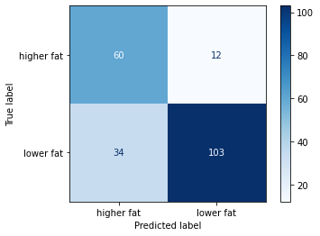

```python
print('Figure 3: Final Model Confusion Matrix')
plot_confusion_matrix(random_knn, X_test, y_test, cmap = "Blues")
```

As expected, our model is maximizing recall score, which leads to a small number of **false negatives** (only **12** predicted lower fat when the true label is higher fat). However, we do have a sacrifice in the form of a higher number of **false positives** (**34** predicted as higher fat when the true label is lower fat).

## Discussion

In this analysis, we developed a model to predict the fat level in canadian cheeses. Based on our results, the **KNN model** with **n_neighbors = 2** provided the highest **validation recall score of 0.85**, which was our key evaluation metric.

When we scored the optimized model against our test data, we achieved a **recall score of 0.83** along with an **accuracy of 0.78**. Our dummy model achieved a **recall score of 0.00** so that comparison is not very valuable, however the dummy model's **accuracy of 0.66** was significantly improved upon by the final model.

Overall the results were interesting and not exactly as expected. The KNN model is more simple than the SVC and random forest models, so it was interesting that it scored the highest on recall in the training section. This is possibly due to the limited number of features (7) we used in our model.

In the future, there are some potential areas to explore:

- Due to system limitations, we did a relatively simple hyperparameter optimization. We used randomized search rather than grid search, we limited our iterations to 50, and we used a maximum of 2 hyperparameters to optimize for each model. With more time/computational resources, we could do a more comprehensive hyperparameter optimization with grid search, all hyperparameters, and a wider range for possible hyperparameter values. This could potentially increase the scoring of our models, especially for the more complex SVC and random forest models.
- We could also explore the use of a decision tree to help visualize the results and identify the most influential features that drive fat level in cheeses.

## References

- All work in this project is original. Data sources are listed below:

### Resources Used

- [Government of Canada Data Source](https://open.canada.ca/data/en/dataset/3c16cd48-3ac3-453f-8260-6f745181c83b)
  - Dataset from the Agriculture and Agri-Food Canada section. Note: dataset is no longer available from this link.
- [Sklearn Classifier Comparison](https://scikit-learn.org/stable/auto_examples/classification/plot_classifier_comparison.html)
  - Comparison of a variety of classifier models.